# Analyze A/B Test Results

Contents:

- Introduction
- Part I - Probability
- Part II - A/B Test
- Part III - Regression

## Introduction

A/B tests are very commonly performed by data analysts and data scientists. For this project, I will be working to understand the results of an A/B test run by an e-commerce website. The goal is to work through this notebook to help the company understand if they should:

- Implement the new webpage,
- Keep the old webpage, or
- Perhaps run the experiment longer to make their decision.

## Part I - Probability

To get started, let's import our libraries.

```python
import pandas as pd
import numpy as np
import random
import matplotlib.pyplot as plt
%matplotlib inline
#We are setting the seed to assure you get the same answers on quizzes as we set up
random.seed(42)
```

[output not shown]

**a.** Reading in the dataset from the `ab_data.csv` file

```python
df = pd.read_csv('ab_data.csv')
df.head()
```

|  | user_id | timestamp | group | landing_page | converted |
| --- | --- | --- | --- | --- | --- |
| 0 | 851104 | 2017-01-21 22:11:48.556739 | control | old_page | 0 |
| 1 | 804228 | 2017-01-12 08:01:45.159739 | control | old_page | 0 |
| 2 | 661590 | 2017-01-11 16:55:06.154213 | treatment | new_page | 0 |
| 3 | 853541 | 2017-01-08 18:28:03.143765 | treatment | new_page | 0 |
| 4 | 864975 | 2017-01-21 01:52:26.210827 | control | old_page | 1 |

**b.** Used the cell below to find the number of rows in the dataset.

```python
df.info()
```

```
<class 'pandas.core.frame.DataFrame'>
RangeIndex: 294478 entries, 0 to 294477
Data columns (total 5 columns):
user_id         294478 non-null int64
timestamp       294478 non-null object
group           294478 non-null object
landing_page    294478 non-null object
converted       294478 non-null int64
dtypes: int64(2), object(3)
memory usage: 11.2+ MB
```

**c.** The number of unique users in the dataset.

```python
df.user_id.nunique()
```

```
290584
```

**d.** The proportion of users converted.

```python
print(df.converted.value_counts(0))

converted = df[df['converted']== True].shape[0]/df.shape[0]
notconverted = df[df['converted']== False].shape[0]/df.shape[0]

converted, notconverted
```

```
0    259241
1     35237
Name: converted, dtype: int64
```

```
(0.11965919355605512, 0.8803408064439449)
```

**e.** The number of times when the "group" is `treatment` but "landing_page" is not a `new_page`.

```python
treatment_not_new = df[((df['group'] == 'treatment') & (df['landing_page'] != 'new_page')) | ((df['group'] != 'treatment') & (df['landing_page'] == 'new_page'))].shape[0]
treatment_not_new
```

```
3893
```

**f.** Do any of the rows have missing values?

```python
df[df.isnull().any(axis=1)].shape[0]
```

```
0
```

In a particular row, the **group** and **landing_page** columns should have either of the following acceptable values:

| user_id | timestamp | group | landing_page | converted |
| --- | --- | --- | --- | --- |
| XXXX | XXXX | `control` | `old_page` | X |
| XXXX | XXXX | `treatment` | `new_page` | X |

It means, the `control` group users should match with `old_page`; and `treatment` group users should matched with the `new_page`.

However, for the rows where `treatment` does not match with `new_page` or `control` does not match with `old_page`, we cannot be sure if such rows truly received the new or old wepage.

```python
# I Removed the inaccurate rows, and store the result in a new dataframe df2
df2 = df[((df['group'] == 'control') & (df['landing_page'] == 'old_page')) | ((df['group'] == 'treatment') & (df['landing_page'] == 'new_page'))]
df2.head()
```

|  | user_id | timestamp | group | landing_page | converted |
| --- | --- | --- | --- | --- | --- |
| 0 | 851104 | 2017-01-21 22:11:48.556739 | control | old_page | 0 |
| 1 | 804228 | 2017-01-12 08:01:45.159739 | control | old_page | 0 |
| 2 | 661590 | 2017-01-11 16:55:06.154213 | treatment | new_page | 0 |
| 3 | 853541 | 2017-01-08 18:28:03.143765 | treatment | new_page | 0 |
| 4 | 864975 | 2017-01-21 01:52:26.210827 | control | old_page | 1 |

```python
# Double Checked all of the incorrect rows were removed from df2 -
df2[((df2['group'] == 'treatment') == (df2['landing_page'] == 'new_page')) == False].shape[0]
```

```
0
```

**a.** How many unique **user_id**s are in **df2**?

```python
df2.user_id.nunique()
```

```
290584
```

**b.** There is one **user_id** repeated in **df2**. What is it?

```python
nonunique = df2[df2.duplicated('user_id')]['user_id']
nonunique
```

```
2893    773192
Name: user_id, dtype: int64
```

**c.** Displayed the rows for the duplicate **user_id**

```python
df2[df2.duplicated('user_id')]
```

|  | user_id | timestamp | group | landing_page | converted |
| --- | --- | --- | --- | --- | --- |
| 2893 | 773192 | 2017-01-14 02:55:59.590927 | treatment | new_page | 0 |

**d.** Removed **one** of the rows with a duplicate **user_id**, from the **df2** dataframe.

```python
# Removed one of the rows with a duplicate user_id..
df2 = df2.drop_duplicates(subset='user_id', keep='first')


# Checked again if the row with a duplicate user_id is deleted or not
id_has_duplicates = df2.duplicated(subset='user_id').any()
id_has_duplicates

if id_has_duplicates:
    print("Duplicate user_id values still exist in df2.")
else:
    print("No duplicate user_id values found in df2.")
```

```
No duplicate user_id values found in df2.
```

### Probability

**a.** What is the probability of an individual converting regardless of the page they receive?

```python
p_pop = df2['converted'].mean()
p_pop
```

```
0.11959708724499628
```

**b.** Given that an individual was in the `control` group, what is the probability they converted?

```python
control = df2[df2['group']== 'control']
p_control_converted = control['converted'].mean()
p_control_converted
```

```
0.1203863045004612
```

**c.** Given that an individual was in the `treatment` group, what is the probability they converted?

```python
treatment = df2[df2['group'] == 'treatment']
p_treatment_converted = treatment['converted'].mean()
p_treatment_converted
```

```
0.11880806551510564
```

```python
# Calculate the actual difference (obs_diff) between the conversion rates for the two groups.
obs_diff = p_control_converted - p_treatment_converted
obs_diff
```

```
0.0015782389853555567
```

**d.** What is the probability that an individual received the new page?

```python
new_page_count = len(df2[df2['landing_page'] == 'new_page'])
total_count = len(df2)
p_new_page_received = new_page_count / total_count
print(p_new_page_received)
```

```
0.5000619442226688
```

> To determine whether the new treatment group leads to more conversions, I need to compare the conversion rates of the treatment group (users who received the new page) and the control group (users who received the old page). As their difference showing, "p_control_converted" is higher than "p_treatment_converted", it would suggest that the old page (control group) leads to more conversions. To make a final conclusion, we also need to consider the proportion of users who received the new page "p_new_page_received". If "p_new_page_received" is very low, even if p_treatment_converted is higher, it may not have a significant impact overall if only a small portion of users received the new page.

> Therefore, to determine whether the new treatment group users lead to more conversions, I compare "p_treatment_converted" and "p_control_converted" while considering "p_new_page_received" and the "overall proportion of users" in each group.

## Part II - A/B Test

> Based on the provided information and the assumption that the old page is better unless the new page proves to be definitely better at a Type I error rate of 5%, here is the null and alternative hypotheses:

> **Alternative Hypothesis ($H_{1}$)**: The converted probability (or rate) for the new page is greater than the converted probability (or rate) for the old page. In terms of $p_{old}$ and $p_{new}$ it can be stated as:

> $H_{1}$: $p_{new}$ > $p_{old}$

### ToDo 2.2 - Null Hypothesis $H_0$ Testing

Under the null hypothesis $H_0$, assuming that $p_{new}$ and $p_{old}$ are equal. Furthermore, assuming that $p_{new}$ and $p_{old}$ both are equal to the **converted** success rate in the `df2` data regardless of the page. So, our assumption is:

$p_{new}$ = $p_{old}$ = $p_{population}$

In this section:

**a.** What is the **conversion rate** for $p_{new}$ under the null hypothesis?

```python
p_new_null = p_pop
p_new_null
```

```
0.11959708724499628
```

**b.** What is the **conversion rate** for $p_{old}$ under the null hypothesis?

```python
p_old_null = p_pop
p_old_null
```

```
0.11959708724499628
```

**c.** What is $n_{new}$, the number of individuals in the treatment group?

```python
n_new = len(df2[df2['group'] == 'treatment'])
print(n_new)
```

```
145310
```

**d.** What is $n_{old}$, the number of individuals in the control group?

```python
n_old = len(df2[df2['group'] == 'control'])
print(n_old)
```

```
145274
```

**e. Simulating Sample for the `treatment` Group**  
Simulated $n_{new}$ transactions with a conversion rate of $p_{new}$ under the null hypothesis.

```python
# Simulate n_new transactions with conversion rate p_null
new_page_converted = np.random.choice([1, 0], size=n_new, p=[p_new_null, 1 - p_new_null])

new_page_converted
```

```
array([0, 0, 1, ..., 1, 1, 0])
```

**f. Simulating Sample for the `control` Group**  
Simulated $n_{old}$ transactions with a conversion rate of $p_{old}$ under the null hypothesis.

```python
# Simulate a Sample for the control Group
old_page_converted = np.random.choice([1, 0], size=n_old, p=[p_old_null, 1 - p_old_null])

old_page_converted
```

```
array([0, 0, 0, ..., 0, 0, 0])
```

**g.** The difference in the "converted" probability $(p{'}_{new}$ - $p{'}_{old})$ for simulated samples from the parts (e) and (f) above.

```python
p_new_sample = new_page_converted.mean()
p_old_sample = old_page_converted.mean()
obs_diff = p_new_sample - p_old_sample
obs_diff
```

```
0.0018424629601773296
```

```python
p_diffs = []
p_new = df2[df2['group'] == 'treatment']['converted'].mean()
p_old = df2[df2['group'] == 'control']['converted'].mean()
n_new = len(df2[df2['group'] == 'treatment'])
n_old = len(df2[df2['group'] == 'control'])

for _ in range(10000):
    sample_new = np.random.binomial(n_new, p_new)
    sample_old = np.random.binomial(n_old, p_old)
    p_diffs.append(sample_new / n_new - sample_old / n_old)
```

```python
p_diffs = np.array(p_diffs)
p_diffs.mean()
```

```
-0.00155816330450338
```

**i. Histogram**  
Plotted a histogram of the **p_diffs**. Does this plot look like what you expected?

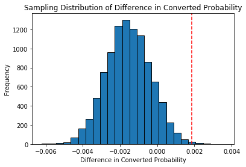

```python
# Plot histogram of p_diffs
plt.hist(p_diffs, bins=25, edgecolor='black')
plt.axvline(obs_diff, color='red', linestyle='dashed', linewidth=1.5)
plt.title('Sampling Distribution of Difference in Converted Probability')
plt.xlabel('Difference in Converted Probability')
plt.ylabel('Frequency')
plt.show()
```

```python
p_value = (p_diffs < obs_diff).mean()
print(p_value)
```

```
0.9973
```

**k.** Computing

- What is this value called in scientific studies?
- What does this value signify in terms of whether or not there is a difference between the new and old pages?

**l. Using Built-in Methods for Hypothesis Testing**  
We could also use a built-in to achieve similar results. Though using the built-in might be easier to code, the above portions are a walkthrough of the ideas that are critical to correctly thinking about statistical significance.

- `convert_old`: number of conversions with the old_page
- `convert_new`: number of conversions with the new_page
- `n_old`: number of individuals who were shown the old_page
- `n_new`: number of individuals who were shown the new_page

```python
import statsmodels.api as sm

# number of conversions with the old_page
convert_old = df2.query("group == 'control' and converted == 1").shape[0]

# number of conversions with the new_page
convert_new = df2.query("group == 'treatment' and converted == 1").shape[0]

# number of individuals who were shown the old_page
n_old = df2.query("group == 'control'").shape[0]

# number of individuals who received new_page
n_new = df2.query("group == 'treatment'").shape[0]

convert_old, convert_new, n_old, n_new
```

```
(17489, 17264, 145274, 145310)
```

**m.** Now I use `sm.stats.proportions_ztest()` to compute test statistic and p-value. [Here](https://www.statsmodels.org/stable/generated/statsmodels.stats.proportion.proportions_ztest.html) is a helpful link on using the built in.

The syntax is:

```
proportions_ztest(count_array, nobs_array, alternative='larger')
```

where,

- `count_array` = represents the number of "converted" for each group
- `nobs_array` = represents the total number of observations (rows) in each group
- `alternative` = choose one of the values from `[‘two-sided’, ‘smaller’, ‘larger’]` depending upon two-tailed, left-tailed, or right-tailed respectively.

  > **Hint**:  
  > It's a two-tailed if you defined $H_1$ as $(p_{new} = p_{old})$.  
  > It's a left-tailed if you defined $H_1$ as $(p_{new} < p_{old})$.  
  > It's a right-tailed if you defined $H_1$ as $(p_{new} > p_{old})$.

The built-in function above will return the z_score, p_value.

### About the two-sample z-test

As I have plotted a distribution `p_diffs` representing the difference in the "converted" probability $(p{'}_{new}-p{'}_{old})$ for two simulated samples 10,000 times.

Another way for comparing the mean of two independent and normal distribution is a **two-sample z-test**. I can perform the Z-test to calculate the Z_score, as shown in the equation below:

$$ Z_{score} = \frac{ (p{'}_{new}-p{'}_{old}) - (p_{new} - p_{old})}{ \sqrt{ \frac{\sigma^{2}_{new} }{n_{new}} + \frac{\sigma^{2}_{old} }{n_{old}} } } $$

where,

- $p{'}$ is the "converted" success rate in the sample
- $p_{new}$ and $p_{old}$ are the "converted" success rate for the two groups in the population.
- $\sigma_{new}$ and $\sigma_{new}$ are the standard deviation for the two groups in the population.
- $n_{new}$ and $n_{old}$ represent the size of the two groups or samples (it's same in our case)

> Z-test is performed when the sample size is large, and the population variance is known. The z-score represents the distance between the two "converted" success rates in terms of the standard error.

Next step is to make a decision to reject or fail to reject the null hypothesis based on comparing these two values:

- $Z_{score}$
- $Z_{\alpha}$ or $Z_{0.05}$, also known as critical value at 95% confidence interval. $Z_{0.05}$ is 1.645 for one-tailed tests, and 1.960 for two-tailed test. You can determine the $Z_{\alpha}$ from the z-table manually.

To Decide if hypothesis is either a two-tailed, left-tailed, or right-tailed test. Accordingly, reject OR fail to reject the null based on the comparison between $Z_{score}$ and $Z_{\alpha}$. We determine whether or not the $Z_{score}$ lies in the "rejection region" in the distribution. In other words, a "rejection region" is an interval where the null hypothesis is rejected iff the $Z_{score}$ lies in that region.

> Hint:  
> For a right-tailed test, reject null if $Z_{score}$ > $Z_{\alpha}$.  
> For a left-tailed test, reject null if $Z_{score}$ < $Z_{\alpha}$.

```python
import statsmodels.api as sm

z_score, p_value = sm.stats.proportions_ztest([convert_new, convert_old], [n_new, n_old], alternative='larger')

print("Z-score:", z_score)
print("p-value:", p_value)
print(z_score, p_value)
```

```
Z-score: -1.31092419842
p-value: 0.905058312759
-1.31092419842 0.905058312759
```

**n.** What do the z-score and p-value you computed in the previous question mean for the conversion rates of the old and new pages? Do they agree with the findings in parts **j.** and **k.**?

The z-score and p-value computed in the previous question provide insights into the conversion rates of the old and new pages and help in determining the statistical significance of the observed difference.

The z-score measures the number of standard deviations the observed difference in proportions (conversion rates) is away from the expected difference under the null hypothesis. A positive z-score indicates that the observed difference is in favor of the alternative hypothesis (new page has a higher conversion rate), while a negative z-score would indicate the opposite.

The p-value represents the probability of observing a test statistic as extreme as the one observed (or more extreme) under the null hypothesis. In this case, the p-value represents the probability of observing a difference in conversion rates as extreme as the one observed or more extreme, assuming that the null hypothesis is true (the conversion rates of the old and new pages are equal).

The z-score of -1.3109 indicates that the observed difference in conversion rates between the old and new pages is 1.3109 standard deviations below the mean of the null distribution. The p-value of 0.9051 suggests that, under the null hypothesis, there is a 90.51% probability of observing a difference as extreme as or more extreme than the one observed in the data.

These results indicate that the observed difference in conversion rates is not statistically significant. The p-value of 0.9051 is much larger than the conventional significance level of 0.05, indicating that there is insufficient evidence to reject the null hypothesis. Therefore, these findings agree with the p-value of 0.9, which suggests no significant difference in the conversion rates between the old and new pages.

### Part III - A regression approach

**a.** Since each row in the `df2` data is either a conversion or no conversion:

> Logistic regression is suitable for binary outcomes, where the response variable takes on two possible values, such as conversion (1) or no conversion (0). It models the probability of an event occurring (in this case, conversion) based on the predictor variables.

**b.** The goal is to use **statsmodels** library to fit the regression model

```python
df2['intercept'] = 1
df2['ab_page'] = pd.get_dummies(df2['group'])['treatment']
```

**c.** Used **statsmodels** to instantiate regression model on the two columns I created in part (b). above, then fit the model to predict whether or not an individual converts.

```python
from statsmodels.api import Logit
# Instantiate the logistic regression model
lm = sm.Logit(df2['converted'], df2[['intercept', 'ab_page']])

# Fit the model to predict conversion
results = lm.fit()
```

```
Optimization terminated successfully.
         Current function value: 0.366118
         Iterations 6
```

**d.** Summary

```python
results.summary2()
```

| Model: | Logit | No. Iterations: | 6.0000 |
| --- | --- | --- | --- |
| Dependent Variable: | converted | Pseudo R-squared: | 0.000 |
| Date: | 2023-07-18 08:31 | AIC: | 212780.3502 |
| No. Observations: | 290584 | BIC: | 212801.5095 |
| Df Model: | 1 | Log-Likelihood: | -1.0639e+05 |
| Df Residuals: | 290582 | LL-Null: | -1.0639e+05 |
| Converged: | 1.0000 | Scale: | 1.0000 |

|  | Coef. | Std.Err. | z | P>\|z\| | [0.025 | 0.975] |
| --- | --- | --- | --- | --- | --- | --- |
| intercept | -1.9888 | 0.0081 | -246.6690 | 0.0000 | -2.0046 | -1.9730 |
| ab_page | -0.0150 | 0.0114 | -1.3109 | 0.1899 | -0.0374 | 0.0074 |

**e.** What is the p-value associated with **ab_page**? Why does it differ from the value found in **Part II**?

> The p-value associated with ab_page in the logistic regression model is 0.1899.

The reason why this p-value differs from the one found in Part II is because the hypotheses being tested are different. In Part II, we performed a one-tailed hypothesis test to compare the conversion rates of the old and new pages, where the null hypothesis was that the conversion rate of the new page is less than or equal to the conversion rate of the old page. The alternative hypothesis was that the conversion rate of the new page is greater than the conversion rate of the old page. This resulted in a one-sided p-value.

In contrast, in the logistic regression model, we are testing whether there is a significant association between the page type (ab_page) and the conversion status. The null hypothesis in this case is that there is no association between the page type and the conversion status, while the alternative hypothesis is that there is an association. This results in a two-sided p-value.

The p-value for ab_page in the logistic regression model is 0.1899, which is greater than the Type I error rate (0.05). Therefore, we fail to reject the null hypothesis and conclude that there is not enough evidence to suggest a significant association between the page type and the conversion status.

In summary, the p-value associated with ab_page in the logistic regression model is different from the one in Part II because they are testing different hypotheses (one-sided vs. two-sided) and the logistic regression model considers the association between page type and conversion status rather than the difference in conversion rates between old and new pages.

**f. Considering other things that might influence whether or not an individual converts**

> It is a good idea to consider other factors to add into the regression model because there may be various factors other than just the page type that can influence an individual's conversion behavior. By including additional factors, we can account for the potential confounding variables and better understand the relationship between the predictors and the outcome variable.

Some reasons why it is beneficial to consider other factors in the regression model are:

1. **Control for confounding variables:** Including additional factors allows us to control for potential confounding variables that might be associated with both the predictor (page type) and the outcome (conversion). By accounting for these confounding variables, we can obtain a more accurate estimation of the relationship between the predictor and the outcome.
2. **Improve predictive accuracy:** Adding other factors that are relevant to the outcome variable can enhance the predictive accuracy of the regression model. By capturing more information about the individuals, we can potentially uncover meaningful relationships and improve the model's ability to predict the conversion behavior.
3. **Uncover hidden insights:** Including additional factors can reveal hidden insights and provide a more comprehensive understanding of the factors influencing conversions. By examining the effects of multiple predictors simultaneously, we can identify patterns, interactions, and complex relationships that may not be apparent when considering only one predictor.

However, there are also potential disadvantages to adding additional terms into the regression model:

- **Multicollinearity:** Adding correlated predictors can introduce multicollinearity, where the predictors become highly correlated with each other. This can make it difficult to interpret the individual effects of predictors and may lead to unstable coefficient estimates.
- **Overfitting:** Including too many predictors relative to the sample size can lead to overfitting, where the model becomes too complex and starts capturing noise or idiosyncrasies in the data. Overfitting can result in poor generalization to new data and reduced model performance.
- **Data availability and quality:** Adding additional factors requires having access to relevant data and ensuring its quality. If the additional variables are not available or suffer from missing values or measurement errors, it may affect the validity and reliability of the regression model.

In summary, considering other factors in the regression model can provide valuable insights and improve the model's performance. However, it is important to carefully consider the potential disadvantages, such as multicollinearity, overfitting, and data availability, to ensure that the model remains robust and interpretable.

**g. Adding countries**  
Now along with testing if the conversion rate changes for different pages, I also add an effect based on which country a user lives in.

```python
countries_df = pd.read_csv('countries.csv')
```

```python
df_merged = df2.merge(countries_df, on='user_id', how='left')
```

```python
df_merged[['CA', 'UK', 'US']] = pd.get_dummies(df_merged['country'])
```

```python
df_merged['US_ab']=df_merged['US']*df_merged['ab_page']
df_merged['UK_ab']=df_merged['UK']*df_merged['ab_page']
```

```python
df_merged.head()
```

|  | user_id | timestamp | group | landing_page | converted | intercept | ab_page | country | CA | UK | US | US_ab | UK_ab |
| --- | --- | --- | --- | --- | --- | --- | --- | --- | --- | --- | --- | --- | --- |
| 0 | 851104 | 2017-01-21 22:11:48.556739 | control | old_page | 0 | 1 | 0 | US | 0 | 0 | 1 | 0 | 0 |
| 1 | 804228 | 2017-01-12 08:01:45.159739 | control | old_page | 0 | 1 | 0 | US | 0 | 0 | 1 | 0 | 0 |
| 2 | 661590 | 2017-01-11 16:55:06.154213 | treatment | new_page | 0 | 1 | 1 | US | 0 | 0 | 1 | 1 | 0 |
| 3 | 853541 | 2017-01-08 18:28:03.143765 | treatment | new_page | 0 | 1 | 1 | US | 0 | 0 | 1 | 1 | 0 |
| 4 | 864975 | 2017-01-21 01:52:26.210827 | control | old_page | 1 | 1 | 0 | US | 0 | 0 | 1 | 0 | 0 |

```python
# Fit your model, and summarize the results
logit_model = sm.Logit(df_merged['converted'], df_merged[['intercept', 'ab_page', 'UK', 'US','US_ab','UK_ab']])
results = logit_model.fit()
print(results.summary2())
```

```
Optimization terminated successfully.
         Current function value: 0.366109
         Iterations 6
                          Results: Logit
==================================================================
Model:              Logit            No. Iterations:   6.0000
Dependent Variable: converted        Pseudo R-squared: 0.000
Date:               2023-07-18 08:08 AIC:              212782.6602
No. Observations:   290584           BIC:              212846.1381
Df Model:           5                Log-Likelihood:   -1.0639e+05
Df Residuals:       290578           LL-Null:          -1.0639e+05
Converged:          1.0000           Scale:            1.0000
-------------------------------------------------------------------
               Coef.   Std.Err.     z      P>|z|    [0.025   0.975]
-------------------------------------------------------------------
intercept     -2.0040    0.0364  -55.0077  0.0000  -2.0754  -1.9326
ab_page       -0.0674    0.0520   -1.2967  0.1947  -0.1694   0.0345
UK             0.0118    0.0398    0.2957  0.7674  -0.0663   0.0899
US             0.0175    0.0377    0.4652  0.6418  -0.0563   0.0914
US_ab          0.0469    0.0538    0.8718  0.3833  -0.0585   0.1523
UK_ab          0.0783    0.0568    1.3783  0.1681  -0.0330   0.1896
==================================================================
```

> Based on the summary results of the logistic regression model with the interaction terms, here are the conclusions:
1. **Page (ab_page) Effect**: The coefficient for the ab_page variable is -0.0674, which indicates that there is a small negative association between the new page and the conversion rate. However, the p-value for the ab_page variable is 0.1947, suggesting that this association is not statistically significant at a conventional significance level of 0.05. Therefore, there is not enough evidence to conclude that the new page significantly affects the conversion rate on its own.
2. **Country Effects**: The coefficients for the UK and US variables represent the differences in the conversion rate between the respective countries and the baseline (which is assumed to be the reference country, possibly CA). However, neither the UK nor the US variable has a statistically significant relationship with the conversion rate, as indicated by their p-values of 0.7674 and 0.6418, respectively. Therefore, there is no evidence to suggest that the country of the user significantly influences the conversion rate.
3. **Interaction Effects**: The interaction terms US_ab and UK_ab represent the combined effect of the country and page on the conversion rate. However, both interaction terms have p-values above 0.05 (0.3833 for US_ab and 0.1681 for UK_ab), indicating that these interactions are not statistically significant. Thus, there is no evidence to suggest that the combination of country and page significantly affects the conversion rate.

Overall, based on the statistical analysis, there is no significant evidence to conclude that either the page type or the country has a significant impact on conversion. The p-values for these variables are above the Type I error rate (0.05), suggesting that we fail to reject the null hypothesis.

Practically, this means that we do not have enough evidence to support the adoption of the new page or to indicate that users from different countries have different conversion rates. Therefore, there is no strong basis to suggest implementing the new page or targeting specific countries based on the findings of this analysis.

It's important to note that these conclusions are based solely on the statistical analysis and should be considered in conjunction with other factors such as practical considerations, cost-effectiveness, and business goals before making any decisions related to the webpage design or user targeting.

```python
from subprocess import call
call(['python', '-m', 'nbconvert', 'Analyze_ab_test_results_notebook.ipynb'])
```